# 데이터 준비

## 차수 결정

### ACF / PACF 그래프

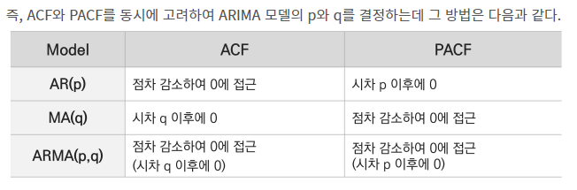

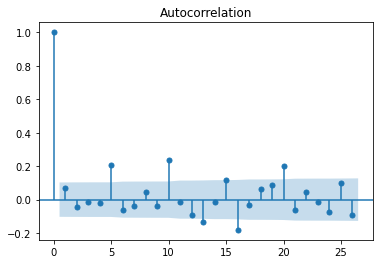

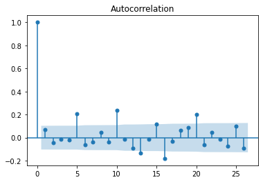

```python
from statsmodels.graphics.tsaplots import plot_acf, plot_pacf
plot_acf(Y_1diff)
# acf는 1 이후에 0에 가까움 --> MA 차수는 1
```

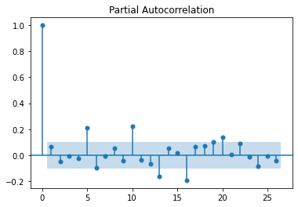

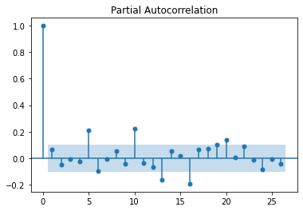

```python
# pacf는 1 이후에 0에 가까움 --> AR 차수는 1
plot_pacf(Y_1diff)
```

### AIC를 이용한 그리드 서치: AIC가 작을수록 좋음

```python
from statsmodels.tsa.arima_model import ARIMA
import itertools
import warnings
warnings.filterwarnings("ignore")

p = range(0,7)
d = range(0,1)
q = range(0,7)
pdq = list(itertools.product(p,d,q))

dict_model ={}
for i in pdq:

    try:
        model = ARIMA(Y_1diff, order=(i))
        model_fit = model.fit(maxiter = 100)
        dict_model[i]=[model_fit.llf, model_fit.aic]

    except:
        print("error lag:",i)

result=pd.DataFrame.from_dict(dict_model, orient ="index", columns =["llf", "AIC"])
```

```
error lag: (3, 0, 4)
```

```python
result.sort_values(by = "AIC", ascending = True) # (6, 0, 6)이 best
```

|  | llf | AIC |
| --- | --- | --- |
| (6, 0, 6) | -2762.193000 | 5552.386001 |
| (5, 0, 4) | -2767.544127 | 5557.088254 |
| (5, 0, 5) | -2767.291775 | 5558.583550 |
| (4, 0, 6) | -2767.500816 | 5559.001633 |
| (6, 0, 4) | -2767.620487 | 5559.240973 |
| (5, 0, 6) | -2767.131829 | 5560.263658 |
| (6, 0, 5) | -2767.169022 | 5560.338044 |
| (6, 0, 2) | -2771.399033 | 5562.798065 |
| (6, 0, 3) | -2771.369657 | 5564.739315 |
| (2, 0, 6) | -2772.730756 | 5565.461512 |
| (3, 0, 6) | -2772.093056 | 5566.186112 |
| (4, 0, 2) | -2775.305185 | 5566.610370 |
| (5, 0, 3) | -2774.476934 | 5568.953867 |
| (5, 0, 2) | -2777.772772 | 5573.545544 |
| (6, 0, 0) | -2778.801941 | 5573.603882 |
| (3, 0, 3) | -2779.201033 | 5574.402066 |
| (5, 0, 1) | -2779.306093 | 5574.612187 |
| (5, 0, 0) | -2780.529747 | 5575.059495 |
| (6, 0, 1) | -2778.796259 | 5575.592518 |
| (2, 0, 5) | -2779.055919 | 5576.111838 |
| (2, 0, 4) | -2780.153814 | 5576.307628 |
| (3, 0, 5) | -2778.486034 | 5576.972067 |
| (4, 0, 3) | -2779.688228 | 5577.376455 |
| (0, 0, 5) | -2782.190036 | 5578.380072 |
| (0, 0, 6) | -2781.415440 | 5578.830880 |
| (4, 0, 5) | -2778.484238 | 5578.968475 |
| (4, 0, 4) | -2779.576866 | 5579.153733 |
| (1, 0, 5) | -2781.803356 | 5579.606712 |
| (1, 0, 6) | -2781.321379 | 5580.642757 |
| (1, 0, 1) | -2787.580718 | 5583.161436 |
| (0, 0, 0) | -2789.858881 | 5583.717762 |
| (0, 0, 1) | -2788.944096 | 5583.888191 |
| (1, 0, 0) | -2789.031459 | 5584.062917 |
| (0, 0, 2) | -2788.518739 | 5585.037478 |
| (1, 0, 2) | -2787.550783 | 5585.101567 |
| (2, 0, 0) | -2788.560105 | 5585.120211 |
| (4, 0, 1) | -2785.576420 | 5585.152841 |
| (1, 0, 4) | -2786.031593 | 5586.063186 |
| (0, 0, 3) | -2788.478981 | 5586.957963 |
| (1, 0, 3) | -2787.529348 | 5587.058695 |
| (3, 0, 0) | -2788.546089 | 5587.092179 |
| (2, 0, 1) | -2788.547685 | 5587.095370 |
| (2, 0, 2) | -2787.553310 | 5587.106619 |
| (0, 0, 4) | -2787.935212 | 5587.870425 |
| (2, 0, 3) | -2787.305335 | 5588.610670 |
| (3, 0, 2) | -2787.308958 | 5588.617917 |
| (4, 0, 0) | -2788.453270 | 5588.906540 |
| (3, 0, 1) | -2788.544042 | 5589.088085 |

## 모델 학습 및 예측

```python
model = ARIMA(Y_1diff, order=(3, 0, 1))
model_fit = model.fit(maxiter = 1000) # 모델 학습

pd.DataFrame({"실제":Y_1diff, "예측":model_fit.predict()})
```

|  | 실제 | 예측 |
| --- | --- | --- |
| 2017-08-28 | 37.365183 | 6.337275 |
| 2017-08-29 | 216.311933 | 8.424635 |
| 2017-08-30 | -12.997600 | 19.605493 |
| 2017-08-31 | 153.267150 | -5.824706 |
| 2017-09-01 | 163.485017 | 15.650900 |
| ... | ... | ... |
| 2018-08-22 | 173.983013 | 2.726573 |
| 2018-08-23 | -140.347500 | 19.890193 |
| 2018-08-24 | 108.764048 | -12.002535 |
| 2018-08-25 | 175.783516 | 19.336548 |
| 2018-08-26 | -46.155064 | 14.382185 |

364 rows × 2 columns

model_fit.forecast() = (forecast, stderr, conf_int)

- forecast: ndarray, Array of out of sample forecasts
- stderr: ndarray, Array of the standard error of the forecasts.
- conf_int: ndarray, 2d array of the confidence interval for the forecast

```python
# forecast를 이용한 예측
model_fit.forecast(steps=7)[0]
```

```
array([-6.72013339,  6.42391462,  7.39600944,  6.55094248,  6.3063976 ,
        6.31494228,  6.33473943])
```

## 잔차 그래프 출력 및 해석

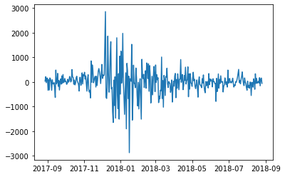

```python
from matplotlib import pyplot as plt
E = Y_1diff -  model_fit.predict()
plt.plot(E)

# 그래프 상에서 편차가 심한 부분 (2017년 12월 ~ 2018년 2월)이 존재 --> 등분산성 만족 못할듯?
```

```python
# 잔차의 평균이 0에 가까움: 편향되지 않았음
E.mean()
```

```
0.001226024198111137
```

```python
# 정상성 검증 --> 정상
print(round(adfuller(E)[1], 4)) # 0.0 --> 정상 시계열 O
```

```
0.0
```

```python
# 정규분포 검증: p value가 0.05 미만이므로 정규분포를 따른다고 보기 힘듦
from scipy import stats
k2, p = stats.normaltest(E)
print(p)
```

```
2.2146371257194384e-14
```

# SARIMA: Seasonal ARIMA

statsmodels.tsa.statespace.sarimax.SARIMAX(endog, exog=None, order=(1, 0, 0), seasonal_order=(0, 0, 0, 0), trend=None, measurement_error=False, time_varying_regression=False, mle_regression=True, simple_differencing=False, enforce_stationarity=True, enforce_invertibility=True, hamilton_representation=False, concentrate_scale=False, trend_offset=1, use_exact_diffuse=False, dates=None, freq=None, missing='none', validate_specification=True, **kwargs)

## seasonal_decompose

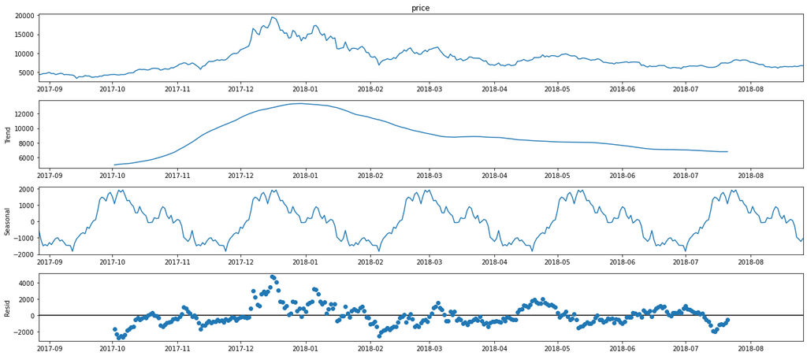

```python
import statsmodels.api as sm
decomposition = sm.tsa.seasonal_decompose(Y, model='additive', period = int(len(Y) / 5)) #
# period: 반복주기 (즉, int(len(Y)/5)는 Y에 주기가 다섯 번 포함되었다는 이야기)
fig = decomposition.plot()
plt.show()
```

## 하이퍼 파라미터 튜닝

```python
p = d = q = range(0, 2)
pdq = list(itertools.product(p, d, q))
seasonal_pdq = [(x[0], x[1], x[2], 12) for x in list(itertools.product(p, d, q))]
print('Examples of parameter for SARIMA...')
print('SARIMAX: {} x {}'.format(pdq[1], seasonal_pdq[1]))
print('SARIMAX: {} x {}'.format(pdq[1], seasonal_pdq[2]))
print('SARIMAX: {} x {}'.format(pdq[2], seasonal_pdq[3]))
print('SARIMAX: {} x {}'.format(pdq[2], seasonal_pdq[4]))
```

```
Examples of parameter for SARIMA...
SARIMAX: (0, 0, 1) x (0, 0, 1, 12)
SARIMAX: (0, 0, 1) x (0, 1, 0, 12)
SARIMAX: (0, 1, 0) x (0, 1, 1, 12)
SARIMAX: (0, 1, 0) x (1, 0, 0, 12)
```

```python
for param in pdq:
    for param_seasonal in seasonal_pdq:
        try:
            mod = sm.tsa.statespace.SARIMAX(Y, order=param,seasonal_order=param_seasonal,enforce_stationarity=False,enforce_invertibility=False)
            results = mod.fit()
            print('ARIMA{}x{}12 - AIC:{}'.format(param,param_seasonal, results.aic))
        except:
            continue
```

```
ARIMA(0, 0, 0)x(0, 0, 0, 12)12 - AIC:7663.9900657544895
ARIMA(0, 0, 0)x(0, 0, 1, 12)12 - AIC:7045.375881101838
ARIMA(0, 0, 0)x(0, 1, 0, 12)12 - AIC:6356.5695456408885
ARIMA(0, 0, 0)x(0, 1, 1, 12)12 - AIC:6151.480055746566
ARIMA(0, 0, 0)x(1, 0, 0, 12)12 - AIC:6372.673237286446
ARIMA(0, 0, 0)x(1, 0, 1, 12)12 - AIC:6357.420106705768
ARIMA(0, 0, 0)x(1, 1, 0, 12)12 - AIC:6168.5347668521
ARIMA(0, 0, 0)x(1, 1, 1, 12)12 - AIC:6153.97851920833
ARIMA(0, 0, 1)x(0, 0, 0, 12)12 - AIC:7380.771233776079
ARIMA(0, 0, 1)x(0, 0, 1, 12)12 - AIC:7080.314675970305
ARIMA(0, 0, 1)x(0, 1, 0, 12)12 - AIC:5982.450328596621
ARIMA(0, 0, 1)x(0, 1, 1, 12)12 - AIC:5788.943439839841
ARIMA(0, 0, 1)x(1, 0, 0, 12)12 - AIC:6014.2643680588935
ARIMA(0, 0, 1)x(1, 0, 1, 12)12 - AIC:5982.271753002396
ARIMA(0, 0, 1)x(1, 1, 0, 12)12 - AIC:5821.368122721085
ARIMA(0, 0, 1)x(1, 1, 1, 12)12 - AIC:5790.766758744484
ARIMA(0, 1, 0)x(0, 0, 0, 12)12 - AIC:5567.438118284642
ARIMA(0, 1, 0)x(0, 0, 1, 12)12 - AIC:5391.693775067902
ARIMA(0, 1, 0)x(0, 1, 0, 12)12 - AIC:5668.7005409398525
ARIMA(0, 1, 0)x(0, 1, 1, 12)12 - AIC:5247.829054863669
ARIMA(0, 1, 0)x(1, 0, 0, 12)12 - AIC:5406.824715885541
ARIMA(0, 1, 0)x(1, 0, 1, 12)12 - AIC:5392.384422095154
ARIMA(0, 1, 0)x(1, 1, 0, 12)12 - AIC:5400.470803331551
ARIMA(0, 1, 0)x(1, 1, 1, 12)12 - AIC:5246.139455805438
ARIMA(0, 1, 1)x(0, 0, 0, 12)12 - AIC:5553.106050609133
ARIMA(0, 1, 1)x(0, 0, 1, 12)12 - AIC:5378.2471870208665
ARIMA(0, 1, 1)x(0, 1, 0, 12)12 - AIC:5646.862388106902
ARIMA(0, 1, 1)x(0, 1, 1, 12)12 - AIC:5233.385729528412
ARIMA(0, 1, 1)x(1, 0, 0, 12)12 - AIC:5407.633259453982
ARIMA(0, 1, 1)x(1, 0, 1, 12)12 - AIC:5378.810647116834
ARIMA(0, 1, 1)x(1, 1, 0, 12)12 - AIC:5401.04663589194
ARIMA(0, 1, 1)x(1, 1, 1, 12)12 - AIC:5232.348676377371
ARIMA(1, 0, 0)x(0, 0, 0, 12)12 - AIC:5583.611583055569
ARIMA(1, 0, 0)x(0, 0, 1, 12)12 - AIC:5414.802189991573
ARIMA(1, 0, 0)x(0, 1, 0, 12)12 - AIC:5672.627388774592
ARIMA(1, 0, 0)x(0, 1, 1, 12)12 - AIC:5262.496933593559
ARIMA(1, 0, 0)x(1, 0, 0, 12)12 - AIC:5408.782388491135
ARIMA(1, 0, 0)x(1, 0, 1, 12)12 - AIC:5408.76591977426
ARIMA(1, 0, 0)x(1, 1, 0, 12)12 - AIC:5395.282323324129
ARIMA(1, 0, 0)x(1, 1, 1, 12)12 - AIC:5261.507137119598
```

[output cut: 9 more lines]

```
ARIMA(1, 1, 0)x(0, 0, 1, 12)12 - AIC:5392.611262140451
ARIMA(1, 1, 0)x(0, 1, 0, 12)12 - AIC:5664.688269143238
ARIMA(1, 1, 0)x(0, 1, 1, 12)12 - AIC:5248.077990030424
ARIMA(1, 1, 0)x(1, 0, 0, 12)12 - AIC:5393.3945036935165
ARIMA(1, 1, 0)x(1, 0, 1, 12)12 - AIC:5393.232971091336
ARIMA(1, 1, 0)x(1, 1, 0, 12)12 - AIC:5386.1172696564845
ARIMA(1, 1, 0)x(1, 1, 1, 12)12 - AIC:5246.945480008049
ARIMA(1, 1, 1)x(0, 0, 0, 12)12 - AIC:5552.881604626817
ARIMA(1, 1, 1)x(0, 0, 1, 12)12 - AIC:5378.398053229088
ARIMA(1, 1, 1)x(0, 1, 0, 12)12 - AIC:5634.8202395021235
ARIMA(1, 1, 1)x(0, 1, 1, 12)12 - AIC:5232.741307005787
ARIMA(1, 1, 1)x(1, 0, 0, 12)12 - AIC:5393.278878856841
ARIMA(1, 1, 1)x(1, 0, 1, 12)12 - AIC:5379.035313522883
ARIMA(1, 1, 1)x(1, 1, 0, 12)12 - AIC:5382.513691214475
ARIMA(1, 1, 1)x(1, 1, 1, 12)12 - AIC:5234.945225173917
```

# MARIMA: Multivariate ARIMA

class statsmodels.tsa.statespace.varmax.VARMAX(endog, exog=None, order=(1, 0), trend='c', error_cov_type='unstructured', measurement_error=False, enforce_stationarity=True, enforce_invertibility=True, trend_offset=1, **kwargs)

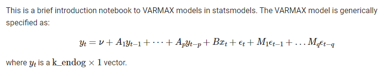

```python
dta = sm.datasets.webuse('lutkepohl2', 'https://www.stata-press.com/data/r12/')
dta.index = dta.qtr
dta.index.freq = dta.index.inferred_freq
endog = dta.loc['1960-04-01':'1978-10-01', ['dln_inv', 'dln_inc', 'dln_consump']]

exog = endog['dln_consump']
# input: endog[['dln_inv', 'dln_inc']], output: exog
mod = sm.tsa.VARMAX(endog[['dln_inv', 'dln_inc']], order=(2,0), trend='n', exog=exog)
res = mod.fit(maxiter=1000, disp=False)
print(res.summary())
```

```
                             Statespace Model Results
==================================================================================
Dep. Variable:     ['dln_inv', 'dln_inc']   No. Observations:                   75
Model:                            VARX(2)   Log Likelihood                 361.039
Date:                    Sat, 04 Sep 2021   AIC                           -696.078
Time:                            13:17:03   BIC                           -665.950
Sample:                        04-01-1960   HQIC                          -684.048
                             - 10-01-1978
Covariance Type:                      opg
===================================================================================
Ljung-Box (L1) (Q):            0.05, 10.15   Jarque-Bera (JB):          11.14, 2.40
Prob(Q):                        0.83, 0.00   Prob(JB):                   0.00, 0.30
Heteroskedasticity (H):         0.45, 0.40   Skew:                      0.16, -0.38
Prob(H) (two-sided):            0.05, 0.03   Kurtosis:                   4.86, 3.44
                            Results for equation dln_inv
====================================================================================
                       coef    std err          z      P>|z|      [0.025      0.975]
------------------------------------------------------------------------------------
L1.dln_inv          -0.2404      0.093     -2.587      0.010      -0.423      -0.058
L1.dln_inc           0.2913      0.449      0.648      0.517      -0.590       1.172
L2.dln_inv          -0.1658      0.155     -1.069      0.285      -0.470       0.138
L2.dln_inc           0.0718      0.421      0.171      0.865      -0.754       0.897
beta.dln_consump     0.9615      0.639      1.505      0.132      -0.290       2.213
                            Results for equation dln_inc
====================================================================================
                       coef    std err          z      P>|z|      [0.025      0.975]
------------------------------------------------------------------------------------
L1.dln_inv           0.0632      0.036      1.765      0.078      -0.007       0.133
L1.dln_inc           0.0816      0.107      0.761      0.447      -0.129       0.292
L2.dln_inv           0.0099      0.033      0.300      0.764      -0.055       0.074
L2.dln_inc           0.0330      0.134      0.246      0.805      -0.230       0.296
beta.dln_consump     0.7755      0.112      6.910      0.000       0.556       0.996
                                  Error covariance matrix
============================================================================================
                               coef    std err          z      P>|z|      [0.025      0.975]
--------------------------------------------------------------------------------------------
sqrt.var.dln_inv             0.0434      0.004     12.301      0.000       0.036       0.050
sqrt.cov.dln_inv.dln_inc   4.79e-05      0.002      0.024      0.981      -0.004       0.004
sqrt.var.dln_inc             0.0109      0.001     11.216      0.000       0.009       0.013
============================================================================================

Warnings:
[1] Covariance matrix calculated using the outer product of gradients (complex-step).
```

```python
res.predict()
```

| qtr | dln_inv | dln_inc |
| --- | --- | --- |
| 1960-04-01 | 0.028275 | 0.028974 |
| 1960-07-01 | 0.035506 | 0.027036 |
| 1960-10-01 | 0.037984 | 0.031099 |
| 1961-01-01 | 0.016717 | 0.024212 |
| 1961-04-01 | -0.020466 | 0.007786 |
| ... | ... | ... |
| 1977-10-01 | 0.024182 | 0.015739 |
| 1978-01-01 | 0.011379 | 0.013705 |
| 1978-04-01 | 0.011913 | 0.017746 |
| 1978-07-01 | 0.004931 | 0.014283 |
| 1978-10-01 | 0.001865 | 0.009078 |

75 rows × 2 columns